# Online Appendix to Amann and Middleditch (2017): **Growth in a Time of Austerity: Evidence from the UK**

Some data manipulations are required to derive the monthly data series used in Amann and Middleditch (2017). Below we provide a discussion of the data derivation process.

# Raw Data

### Gross Government Debt (DoG)

Quarterly data on gross government debt is readily available, e.g ‘*quarterly government debt*’ from Eurostat and ‘*general government total gross debt*’ from the OECDStats.StatExtracts.[^1] However, only the United Kingdom Office of National Statistics (ONS) offers ‘Public Sector Net Debt’ (PSND from now on) on a monthly basis.[^2]

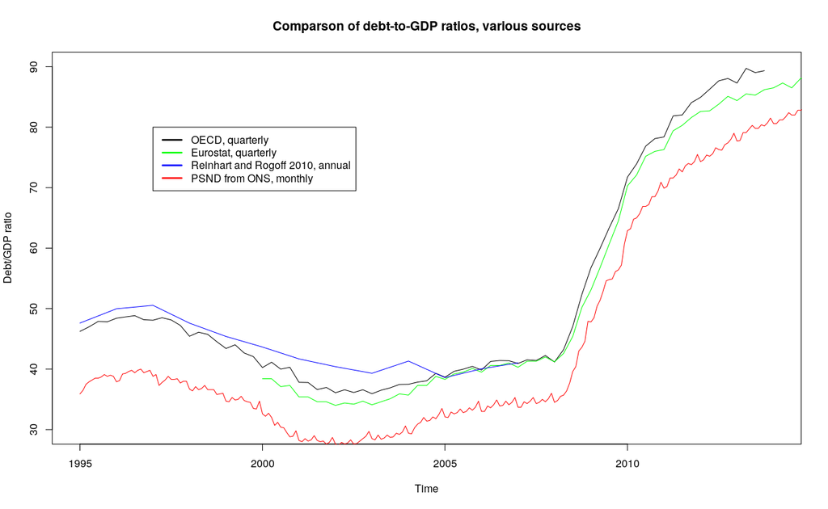

As quarterly gross debt and quarterly PSND data are freely available and in order to generate a monthly gross debt measure, we first extract the difference between the quarterly OECD gross debt measure and the quarterly PSND measure by ONS.

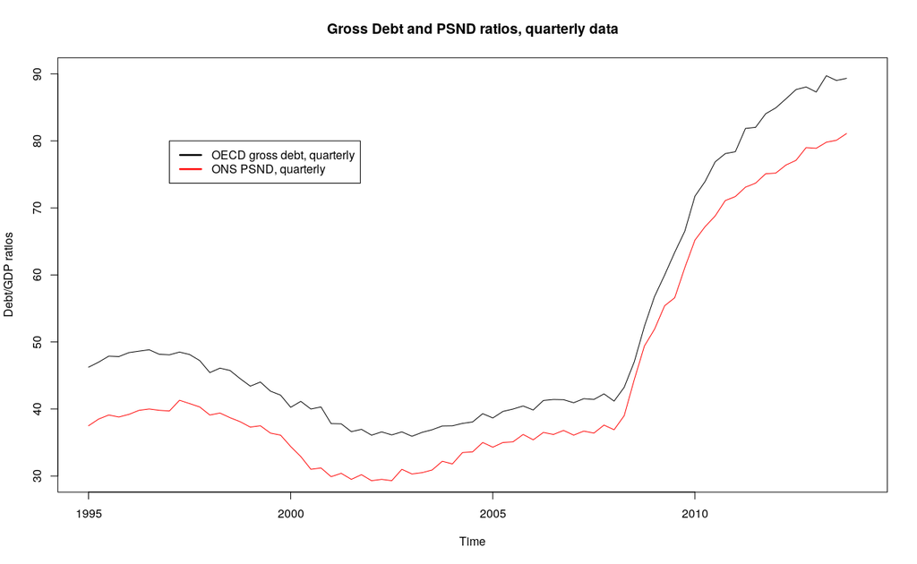

This difference is then disaggregated from quarterly to monthly data using the Denton-Cholette Denton (1971) method through the R (R Foundation for Statistical Computing 2014) package `tempdisagg` (Sax and Steiner 2013).

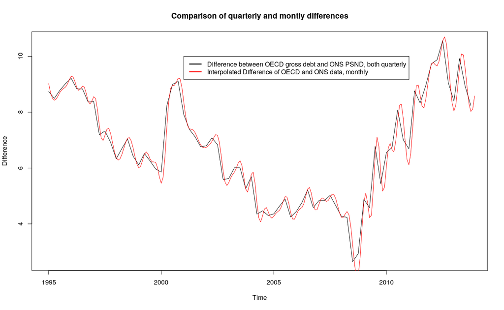

The newly derived monthly difference is then added to the monthly PSND series to generate a close approximation of a monthly gross debt measure (cyan line).

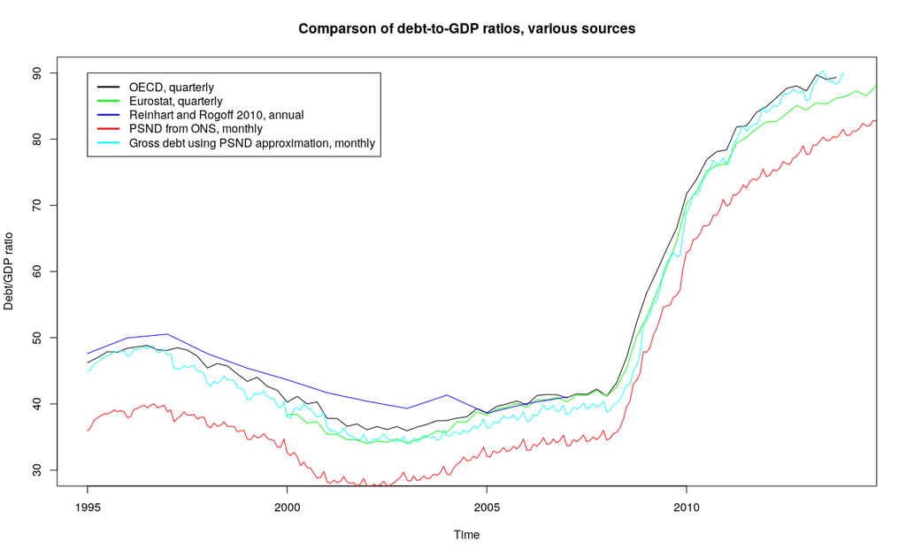

In a last step, we use `Census X-13`, the Seasonal Adjustment Program developed by the United States Census Bureau to seasonally adjust the series using the R package `seasonal` (Sax 2017).

The next figure confirms that the strong seasonal pattern could be removed, thereby producing a smooth(er) series.

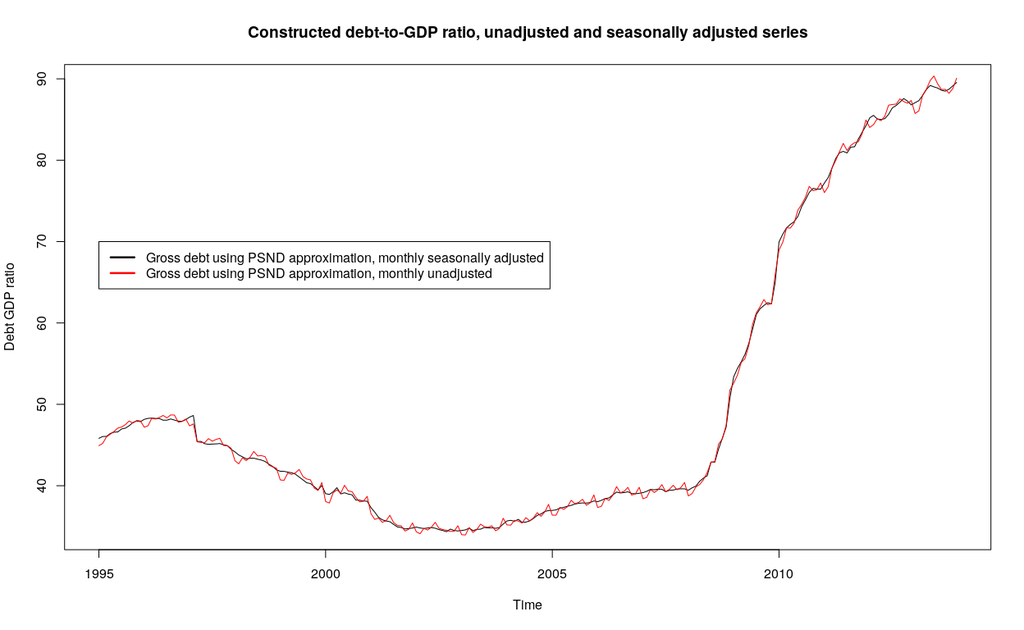

Finally the plot below compares the newly derived monthly DoG series (magenta line) against OECD and Eurostat data.

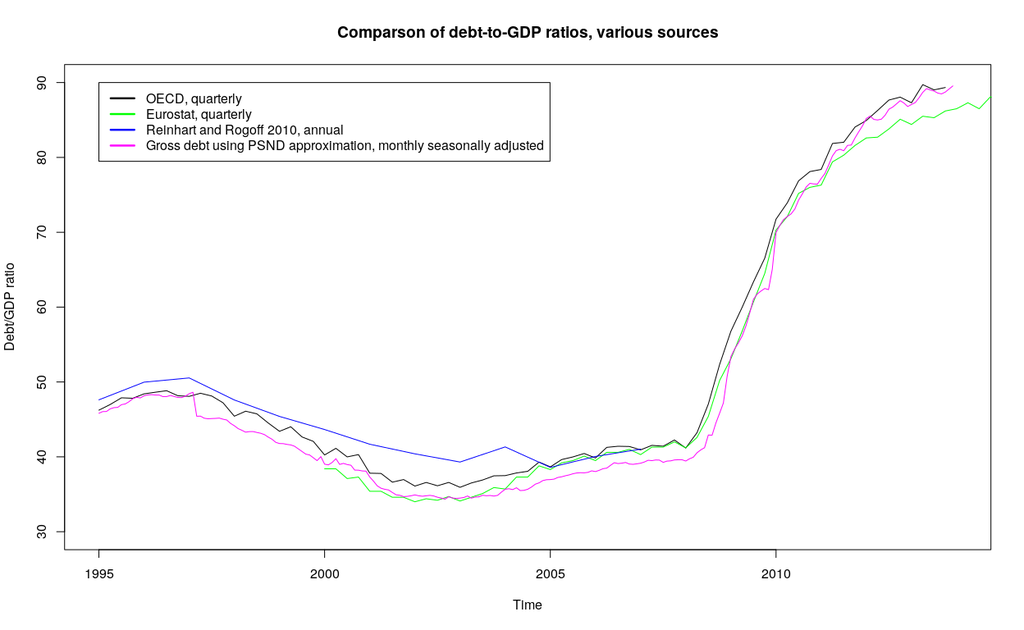

### GDP Growth Rates (GR)

For monthly GDP growth rates, we make use of monthly estimates from the National Institute of Economic and Social Research (NIESR). This series was estimated following the methodology described in Mitchell et al. (2005), expressed as an index where 2008 = 100.

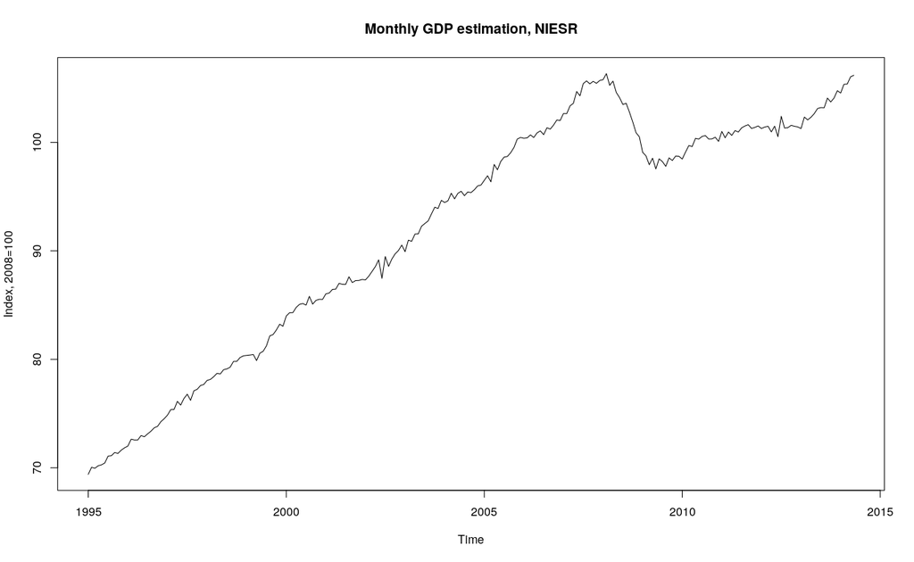

Using these indexed GDP estimates we calculate the percent growth rate in change over the same month of the previous year. Below we compare the monthly measure with GDP growth rates from ONS and the OECD.

In order to compare this calculated series with other GDP measures commonly used by researchers, we plot our monthly series (magenta line) against time and vis-a-vis equivalent GDP growth rates provided by the OECD (black line), ONS (green line), and the corrected Reinhart and Rogoff (2010) data (blue line).[^3]

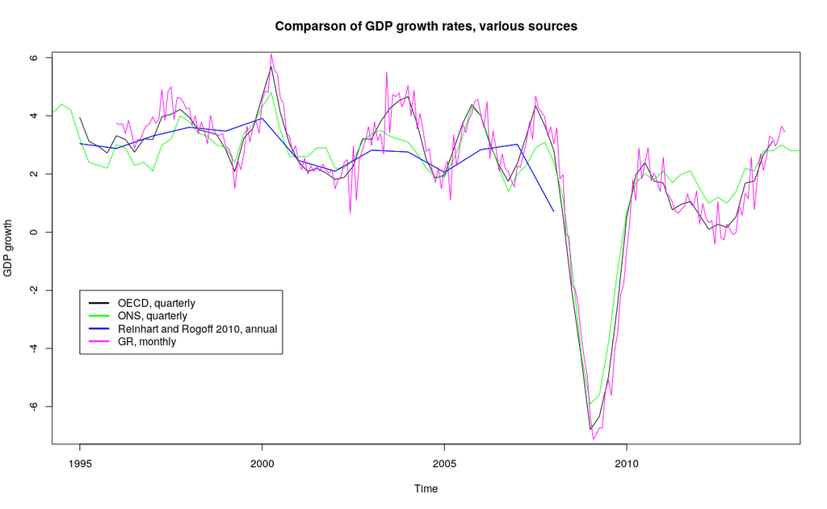

# Final Data

### Summary Statistic

|  | DoG | GR |
| --- | --- | --- |
| Min | 35.60 | -7.12 |
| Max | 89.40 | 6.13 |
| Mean | 51.12 | 2.15 |
| Median | 43.89 | 2.69 |
| SE | 1.14 | 0.16 |
| N | 216 | 216 |

### Exploratory Data Analysis

Below we reproduce Figure 1 in Amann and Middleditch (2017).

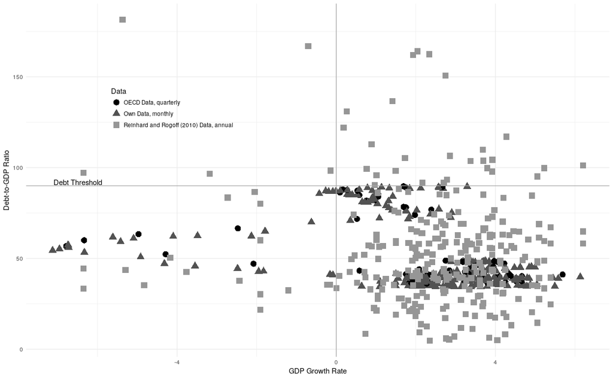

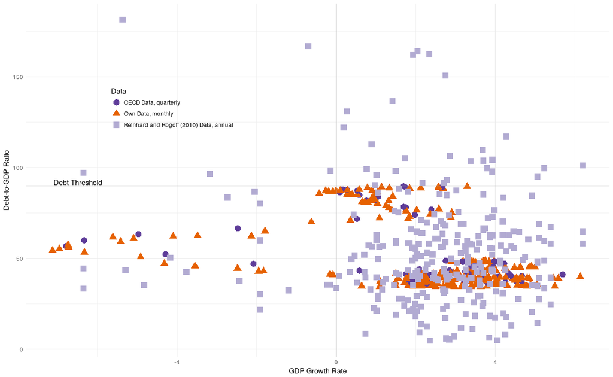

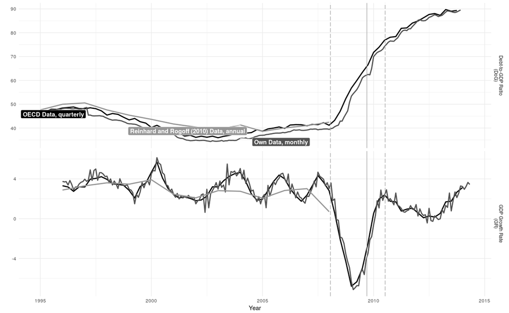

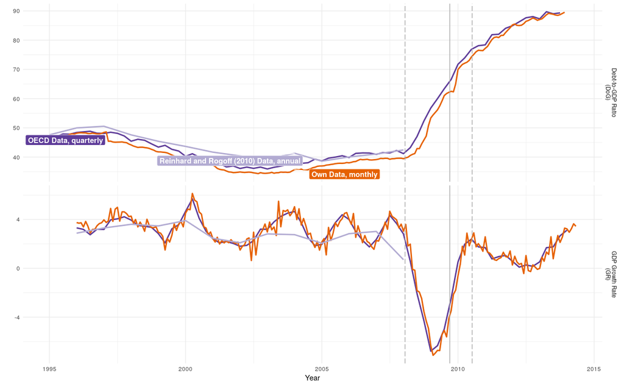

# References and Footnotes

Amann, Juergen, and Paul Middleditch. 2017. “Growth in a Time of Austerity: Evidence from the UK.” Scottish Journal of Political Economy, Forthcoming. http://onlinelibrary.wiley.com/doi/10.1111/sjpe.12132/full.

Denton, Frank T. 1971. “Adjustment of Monthly of Quarterly Series to Annual Totals: An Approach Based on Quadratic Minimizations” 66 (333). Journal of the American Statistical Association: 99–102.

Mitchell, James, Richard J. Smith, Martin R. Weale, Stephen Wright, and Eduardo L. Salazar. 2005. “An Indicator of Monthly GDP and an Early Estimate of Quarterly GDP Growth,” no. 115 (February). Economic Journal: F108–F129.

R Foundation for Statistical Computing. 2014. “R: A Language and Environment for Statistical Computing.” http://www.r-project.org.

Reinhart, Carmen M., and Kenneth S. Rogoff. 2010. “Growth in a Time of Debt” 100 (2). American Economic Review: 573–78.

Sax, Christoph. 2017. “Seasonal: R Interface to X-13-ARIMA-SEATS.” https://cran.r-project.org/package=seasonal%7D.

Sax, Christoph, and Peter Steiner. 2013. “Temporal Disaggregation of Time Series” 5 (2). The R Journal: 80–87.

[^1]: Eurostat data: The full data set including meta data can be downloaded from http://ec.europa.eu/eurostat/data/database (last visit March 2017). OECD.StatExtract quarterly National Accounts (Quarterly Public Sectors Debt, percent of GDP; data can be found at http://stats.oecd.org/Index.aspx?DataSetCode=QASA_TABLE7PSD (last visit March 2017).
[^2]: This data is available at http://www.quandl.com/UKONS/PUSF_HF6X_M-PSND-excluding-NR-as-a-of-GDP-Monthly (last visit March 2017) .
[^3]: The OECD data series, ‘*quarterly growth rates of real GDP, changes over same quarter, previous year*’, is taken from http://stats.oecd.org/index.aspx?queryid=26674 (last visit March 2017). Data from ONS, ‘*gross domestic product: quarter on quarter previous year: CVM SA (Quarterly)*’, is taken from https://www.ons.gov.uk/economy/grossdomesticproductgdp/timeseries/ihyq (last visit March 2017).